# 601_Final Project

Final project with final analysis results as a part of the course “Data Science Fundamentals”

Rahul Gundeti (Graduate student, Data Analytics & Computational Social Sciences (DACSS), UMass Amherst.)  
2022-05-12

# Introduction to Dataset:

The dataset that I have choose to work on is related to startup ecosystem. The word startup has become so popular in he last 5 years that everyone knows about them which is very obvious because of the digitization and the technological advancements and people adapting to the modern way of life. Unlike the olden days hardships, humans are leading a very comfortable life. Everything is at their fingertip and if there is anything they feel short of then there comes a startup to solve that problem and help us to live a very comfortable life.

There are many companies that have become a part of our day to day life. It is very much likely that some have become very synonymous that we are using the startup name more than the actual word just like how google replaced the term search on the net.

My dataset talks about a fraction of those startups that are prominent in India but also has its market presence outside of India.

I have found the dataset on kaggle.

# What my dataset contains?

Date: Time period in the date format (DD/MM/YYYY)

StartupName: Name of the Startup

IndustryVertical: Which industry the startup is working in

SubVertical: Which sub-industry the industry is categorized

CityLocation: where the startup is headquartered

Investors: Who invested in the startup

InvestmentType: What type of investement it was

AmountUSD: How much amount the startup raised in USD

# What I want to do with the dataset?

I am looking to understand certain patterns from my analysis and answer the below questions:

1. Which startup received the most funding?
2. Which Industry Vertical received th most funding?
3. Does location really matter to raise funding?
4. Which type of funding is most prominent among startups?

```r
library(tidyverse)
library(glue)
library(leaflet)
library(ggplot2)
library(lubridate)
library(plotly)
library(scales)
library(zoo)
library(plyr)
library(kableExtra)
library(cowplot)
library(splitstackshape)
```

```r
input <- read.csv("C:/Users/gunde/Downloads/Indian_Startup_Funding.csv",stringsAsFactors = TRUE)
startup <- data.frame(input)
glimpse(startup)
```

```
Rows: 3,044
Columns: 8
$ Date             <fct> 09/01/2020, 13/01/2020, 09/01/2020, 02/01/2~
$ StartupName      <fct> BYJUS, Shuttl, Mamaearth, WealthBucket, Fas~
$ IndustryVertical <fct> "E-Tech", "Transportation", "E-commerce", "~
$ SubVertical      <fct> "E-learning", "App based shuttle service", ~
$ CityLocation     <fct> "Bangalore", "Gurgaon", "Bangalore", "New D~
$ Investors        <fct> "Tiger Global Management", "Susquehanna Gro~
$ InvestmentType   <fct> Private Equity Round, Series C, Series B, P~
$ AmountUSD        <fct> "20,00,00,000", "80,48,394", "1,83,58,860",~
```

```r
#check NA availability for each column
colSums(is.na(startup))
```

```
            Date      StartupName IndustryVertical      SubVertical
               0                0                0                0
    CityLocation        Investors   InvestmentType        AmountUSD
               0                0                0                0
```

```r
class(startup)
```

```
[1] "data.frame"
```

```r
dim(startup)
```

```
[1] 3044    8
```

```r
glimpse(startup)
```

```
Rows: 3,044
Columns: 8
$ Date             <fct> 09/01/2020, 13/01/2020, 09/01/2020, 02/01/2~
$ StartupName      <fct> BYJUS, Shuttl, Mamaearth, WealthBucket, Fas~
$ IndustryVertical <fct> "E-Tech", "Transportation", "E-commerce", "~
$ SubVertical      <fct> "E-learning", "App based shuttle service", ~
$ CityLocation     <fct> "Bangalore", "Gurgaon", "Bangalore", "New D~
$ Investors        <fct> "Tiger Global Management", "Susquehanna Gro~
$ InvestmentType   <fct> Private Equity Round, Series C, Series B, P~
$ AmountUSD        <fct> "20,00,00,000", "80,48,394", "1,83,58,860",~
```

```r
startup$AmountUSD <- as.numeric(gsub(",","",startup$AmountUSD))
```

```r
colSums(is.na(startup))
```

```
            Date      StartupName IndustryVertical      SubVertical
               0                0                0                0
    CityLocation        Investors   InvestmentType        AmountUSD
               0                0                0                0
```

```r
## Convert Date variable to Date format
startup$Date <- as.Date(startup$Date,format("%d/%m/%Y"))
## Confirm
str(startup)
```

```
'data.frame':   3044 obs. of  8 variables:
 $ Date            : Date, format: "2020-01-09" ...
 $ StartupName     : Factor w/ 2453 levels "#Fame","121Policy",..: 276 1911 1308 2307 656 1579 2441 568 295 495 ...
 $ IndustryVertical: Factor w/ 878 levels "360-degree view creating platform",..: 200 827 190 275 254 440 358 822 191 7 ...
 $ SubVertical     : Factor w/ 1943 levels "\"Women\\\\'s Fashion Clothing Online Platform\"",..: 461 75 1647 1279 515 1487 1216 28 112 1681 ...
 $ CityLocation    : Factor w/ 100 levels "Agra","Ahemadabad",..: 5 29 5 62 55 19 29 74 29 5 ...
 $ Investors       : Factor w/ 2405 levels " Sandeep Aggarwal, Teruhide Sato",..: 2114 2061 1857 2316 1997 468 218 1827 1523 1365 ...
 $ InvestmentType  : Factor w/ 55 levels "Angel","Angel / Seed Funding",..: 26 43 41 21 36 40 26 40 44 30 ...
 $ AmountUSD       : num  2.00e+08 8.05e+06 1.84e+07 3.00e+06 1.80e+06 ...
```

```r
## Make a new column for year
startup$year <- as.numeric(format(startup$Date,"%Y"))
## Year frequency table
yeartable <- table(startup$year)
yeartable
```

```
2015 2016 2017 2018 2019 2020
 931  993  687  309  111    7
```

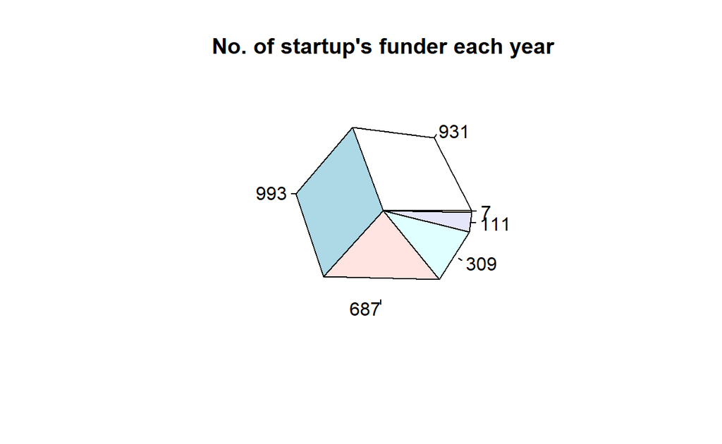

```r
## Visualization using Bar chart
library(plotrix)
pie(yeartable,labels = yeartable, edges=10, main = "No. of startup's funder each year")
```

The pie graph shows the no of startups funded to ratio over the year from 2015 to 2020

```r
head(sort(table(startup$StartupName), decreasing=TRUE),5)
```

```
Ola Cabs   Swiggy    BYJUS    Paytm  Medinfi
       8        8        7        7        6
```

```r
tail(sort(table(startup$StartupName), decreasing=TRUE),5)
```

```
ZuperMeal   Zuppler     Zuver    Zwayam   Zzungry
        1         1         1         1         1
```

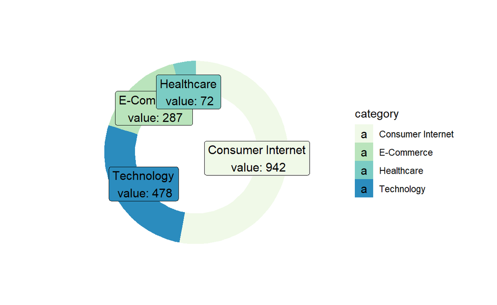

```r
#Creating dataframe
i3 <- data.frame(category = c("Consumer Internet","Technology","E-Commerce","Healthcare"),
                          count = c(942,478,287,72))
#Calculating percentages
i3$fraction <- i3$count / sum(i3$count)
i3$ymax <- cumsum(i3$fraction)
i3$ymin <- c(0, head(i3$ymax, n=-1))
i3$labelPosition <- (i3$ymax + i3$ymin) / 2
i3$label <- paste0(i3$category, "\n value: ", i3$count)

# Make the plot
ggplot(i3, aes(ymax=ymax, ymin=ymin, xmax=4, xmin=3, fill=category)) +
  geom_rect() +
  geom_label( x=3, aes(y=labelPosition, label=label), size=4) +
  scale_fill_brewer(palette=4) +
  coord_polar(theta="y") +
  xlim(c(1, 5)) +
  theme_void()
```

```r
##Industry vertical frequency table
industrytable_tail <- tail(sort(table(startup$IndustryVertical), decreasing=TRUE),25)
industrytable_tail
```

```
                                             Video Games
                                                       1
                             Video Intelligence Platform
                                                       1
                                         Video Streaming
                                                       1
                              Viral Content web Platform
                                                       1
                                                 Virtal
                                                       1
                         Virtual Health consultation app
                                                       1
        Virtual Reality activity based learning platform
                                                       1
                         Virtual Reality Headset creator
                                                       1
virtual reality, 3d simulation and stereoscopic products
                                                       1
                                Visual Blogging platform
                                                       1
                    visual search and discovery platform
                                                       1
                   Voice Call incentivization mobile app
                                                       1
                Warranty Programs Service Administration
                                                       1
                              Waste Management Solutions
                                                       1
                              Wealth Management Platform
                                                       1
                                  Web Content Publishing
                                                       1
                               Wedding Planning Platform
                                                       1
                    Wedding Venues & Vendors Marketplace
                                                       1
                               Weight Management Service
                                                       1
                 WiFi first Cloud communication platform
                                                       1
                                                    wine
                                                       1
                    Women Ethnic Wear Online Marketplace
                                                       1
                             Women Lifestyle Marketplace
                                                       1
                              Womens Fashion Wear Portal
                                                       1
                           Workforce Management Software
                                                       1
```

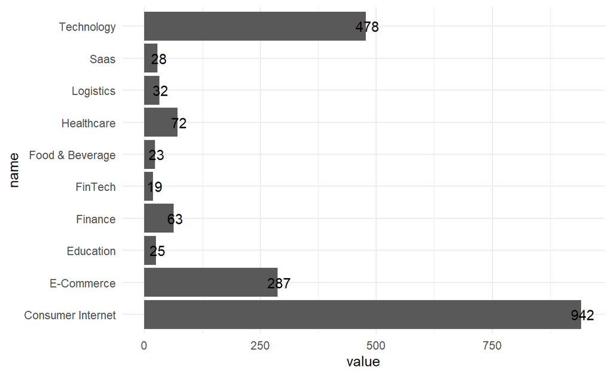

```r
## Visualization using Bar chart
set.seed(5642)
sample_data <- data.frame(name = c("Consumer Internet","Technology","E-Commerce","Healthcare","Finance","Logistics","Saas","Education","Food & Beverage","FinTech") ,
                          value = c(942,478,287,72,63,32,28,25,23,19))

# Create bar plot with labels
plot<-ggplot(sample_data,
             aes(name,value)) +
geom_bar(stat = "identity")+ theme_minimal()+
geom_text(aes(label = signif(value)), nudge_y = 3,)
plot+
coord_flip()
```

If we compare the funding raised it has a very different story all together:

e-commerce start ups are 1/3 in number to consumer internet by they raised almost 4x amounts than consumer internet on average.

```r
Cleanstartup <- startup[complete.cases(startup), ]
head(Cleanstartup)
```

```
        Date  StartupName    IndustryVertical
1 2020-01-09        BYJUS              E-Tech
2 2020-01-13       Shuttl      Transportation
3 2020-01-09    Mamaearth          E-commerce
4 2020-01-02 WealthBucket             FinTech
5 2020-01-02       Fashor Fashion and Apparel
6 2020-01-13        Pando           Logistics
                               SubVertical CityLocation
1                               E-learning    Bangalore
2                App based shuttle service      Gurgaon
3    Retailer of baby and toddler products    Bangalore
4                        Online Investment    New Delhi
5              Embroiled Clothes For Women       Mumbai
6 Open-market, freight management platform      Chennai
                  Investors       InvestmentType AmountUSD year
1   Tiger Global Management Private Equity Round 200000000 2020
2 Susquehanna Growth Equity             Series C   8048394 2020
3     Sequoia Capital India             Series B  18358860 2020
4            Vinod Khatumal         Pre-series A   3000000 2020
5   Sprout Venture Partners           Seed Round   1800000 2020
6         Chiratae Ventures             Series A   9000000 2020
```

```r
dim(Cleanstartup)
```

```
[1] 3038    9
```

```r
summary(Cleanstartup)
```

```
      Date              StartupName            IndustryVertical
 Min.   :2015-01-02   Ola Cabs:   8   Consumer Internet: 941
 1st Qu.:2015-11-03   Swiggy  :   8   Technology       : 478
 Median :2016-07-15   BYJUS   :   7   E-Commerce       : 287
 Mean   :2016-09-22   Paytm   :   7   Healthcare       :  72
 3rd Qu.:2017-06-12   Medinfi :   6   Finance          :  63
 Max.   :2020-01-13   Meesho  :   6   Logistics        :  32
                      (Other) :2996   (Other)          :1165
                    SubVertical      CityLocation
 nan                      : 931   Bangalore:863
 Online Lending Platform  :  11   Mumbai   :609
 Online Pharmacy          :  10   New Delhi:424
 Food Delivery Platform   :   8   Gurgaon  :344
 Education                :   5   Hyderabad:164
 Online Education Platform:   5   Chennai  :142
 (Other)                  :2068   (Other)  :492
                 Investors                 InvestmentType
 Undisclosed Investors: 104   Private Equity      :1355
 Ratan Tata           :  25   Seed Funding        :1350
 Indian Angel Network :  24   Seed/ Angel Funding :  60
 Shell Foundation     :  21   Seed / Angel Funding:  47
 Kalaari Capital      :  16   Seed\\\\nFunding    :  30
 Sequoia Capital      :  15   Debt Funding        :  25
 (Other)              :2833   (Other)             : 171
   AmountUSD             year
 Min.   :1.00e+04   Min.   :2015
 1st Qu.:1.00e+05   1st Qu.:2015
 Median :5.00e+05   Median :2016
 Mean   :1.26e+07   Mean   :2016
 3rd Qu.:4.00e+06   3rd Qu.:2017
 Max.   :3.90e+09   Max.   :2020
```

```r
Cleanstartup1 <- Cleanstartup
str(Cleanstartup1)
```

```
'data.frame':   3038 obs. of  9 variables:
 $ Date            : Date, format: "2020-01-09" ...
 $ StartupName     : Factor w/ 2453 levels "#Fame","121Policy",..: 276 1911 1308 2307 656 1579 2441 568 295 495 ...
 $ IndustryVertical: Factor w/ 878 levels "360-degree view creating platform",..: 200 827 190 275 254 440 358 822 191 7 ...
 $ SubVertical     : Factor w/ 1943 levels "\"Women\\\\'s Fashion Clothing Online Platform\"",..: 461 75 1647 1279 515 1487 1216 28 112 1681 ...
 $ CityLocation    : Factor w/ 100 levels "Agra","Ahemadabad",..: 5 29 5 62 55 19 29 74 29 5 ...
 $ Investors       : Factor w/ 2405 levels " Sandeep Aggarwal, Teruhide Sato",..: 2114 2061 1857 2316 1997 468 218 1827 1523 1365 ...
 $ InvestmentType  : Factor w/ 55 levels "Angel","Angel / Seed Funding",..: 26 43 41 21 36 40 26 40 44 30 ...
 $ AmountUSD       : num  2.00e+08 8.05e+06 1.84e+07 3.00e+06 1.80e+06 ...
 $ year            : num  2020 2020 2020 2020 2020 ...
```

```r
Cleanstartup1$CityLocation <- as.character(Cleanstartup1$CityLocation)
Cleanstartup1$CityLocation[Cleanstartup1$CityLocation != "Bangalore" & Cleanstartup1$CityLocation != "Mumbai" & Cleanstartup1$CityLocation != "New Delhi" & Cleanstartup1$CityLocation != "Gurgaon" & Cleanstartup1$CityLocation != "Pune" & Cleanstartup1$CityLocation != "Hyderabad"] <- "Others"


head(Cleanstartup1)
```

```
        Date  StartupName    IndustryVertical
1 2020-01-09        BYJUS              E-Tech
2 2020-01-13       Shuttl      Transportation
3 2020-01-09    Mamaearth          E-commerce
4 2020-01-02 WealthBucket             FinTech
5 2020-01-02       Fashor Fashion and Apparel
6 2020-01-13        Pando           Logistics
                               SubVertical CityLocation
1                               E-learning    Bangalore
2                App based shuttle service      Gurgaon
3    Retailer of baby and toddler products    Bangalore
4                        Online Investment    New Delhi
5              Embroiled Clothes For Women       Mumbai
6 Open-market, freight management platform       Others
                  Investors       InvestmentType AmountUSD year
1   Tiger Global Management Private Equity Round 200000000 2020
2 Susquehanna Growth Equity             Series C   8048394 2020
3     Sequoia Capital India             Series B  18358860 2020
4            Vinod Khatumal         Pre-series A   3000000 2020
5   Sprout Venture Partners           Seed Round   1800000 2020
6         Chiratae Ventures             Series A   9000000 2020
```

```r
table(Cleanstartup1$CityLocation)
```

```
Bangalore   Gurgaon Hyderabad    Mumbai New Delhi    Others      Pune
      863       344       164       609       424       528       106
```

```r
startup2 <- Cleanstartup1
startup2$IndustryVertical <- as.character(startup2$IndustryVertical)
#clean code
startup2$IndustryVertical[startup2$IndustryVertical != "Consumer Internet" & startup2$IndustryVertical != "Technology" & startup2$IndustryVertical != "ECommerce" & startup2$IndustryVertical != "Logistics" & startup2$IndustryVertical != "Education" & startup2$IndustryVertical != "Healthcare"] <- "OtherSectors"

table(startup2$IndustryVertical)
```

```
Consumer Internet         Education        Healthcare
              941                25                72
        Logistics      OtherSectors        Technology
               32              1490               478
```

```r
TopIT <- table(startup2$InvestmentType)
TopIT.df <- as.data.frame(TopIT)
top10IT <- top_n(TopIT.df,10)
top10IT
```

```
                   Var1 Freq
1          Debt Funding   25
2        Private Equity 1355
3  Seed / Angel Funding   47
4          Seed Funding 1350
5   Seed/ Angel Funding   60
6    Seed/Angel Funding   23
7      Seed\\\\nFunding   30
8              Series A   25
9              Series B   21
10             Series C   14
```

```r
sum(startup2$AmountUSD)
```

```
[1] 38277567120
```

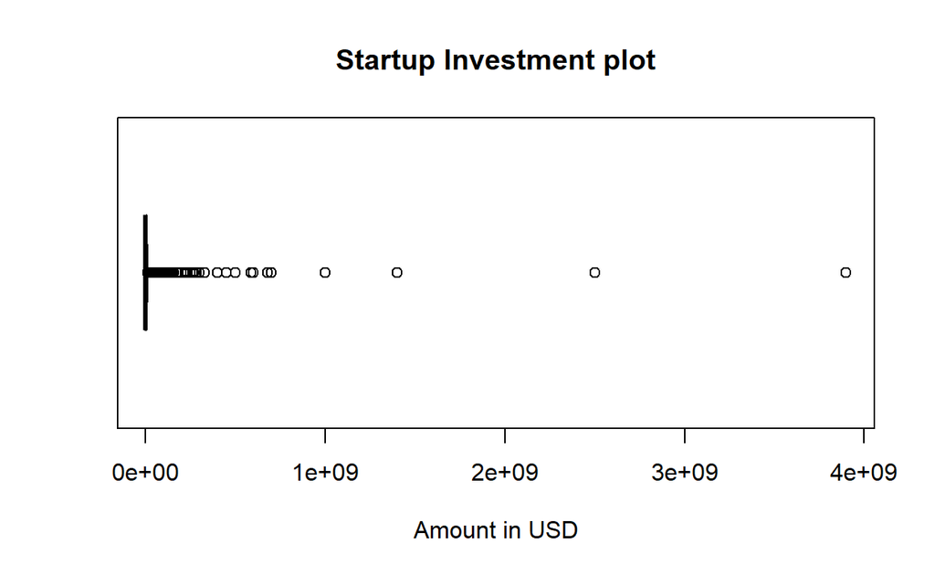

```r
boxplot(startup2$AmountUSD, horizontal = TRUE, xlab = "Amount in USD", main = "Startup Investment plot")
```

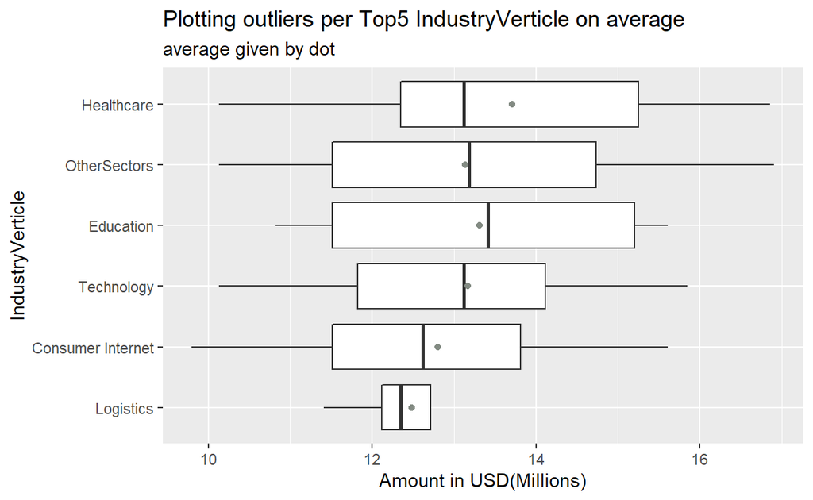

```r
temp = startup2[complete.cases(startup2),] %>% filter(CityLocation == startup2$CityLocation[3])

#Looking for outliers in the data and removing them
outliers = boxplot(temp$AmountUSD ~ temp$IndustryVertical, plot=FALSE)$out
temp.out = temp[-which(temp$AmountUSD %in% outliers),]

# Plotting a boxplot
p2 = ggplot(temp.out, aes(x = reorder(IndustryVertical, AmountUSD), y = log(AmountUSD))) +
  geom_boxplot(outlier.shape = NA, show.legend = FALSE) + coord_flip() +
  stat_summary(fun = mean, col = "honeydew4", geom = 'point') +
  labs(x = "IndustryVerticle", y = "Amount in USD(Millions)", title = "Plotting outliers per Top5 IndustryVerticle on average", subtitle = "average given by dot")
p2
```

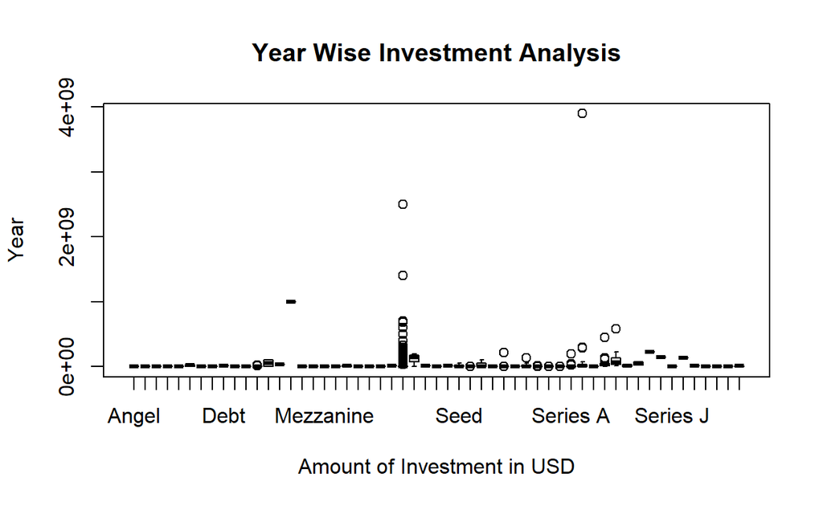

```r
boxplot(startup2$AmountUSD ~ startup2$InvestmentType, horizontal = FALSE, xlab= "Amount of Investment in USD", ylab = "Year", main = "Year Wise Investment Analysis")
```

[figure not shown]

```r
boxplot(startup2$SubVertical ~ startup2$CityLocation,horizontal = TRUE, ylab= "Amount of Investment in USD", xlab = "Industry Sector", main = "Industrial Sector Wise Investment Analysis", boxwex = 0.5)
```

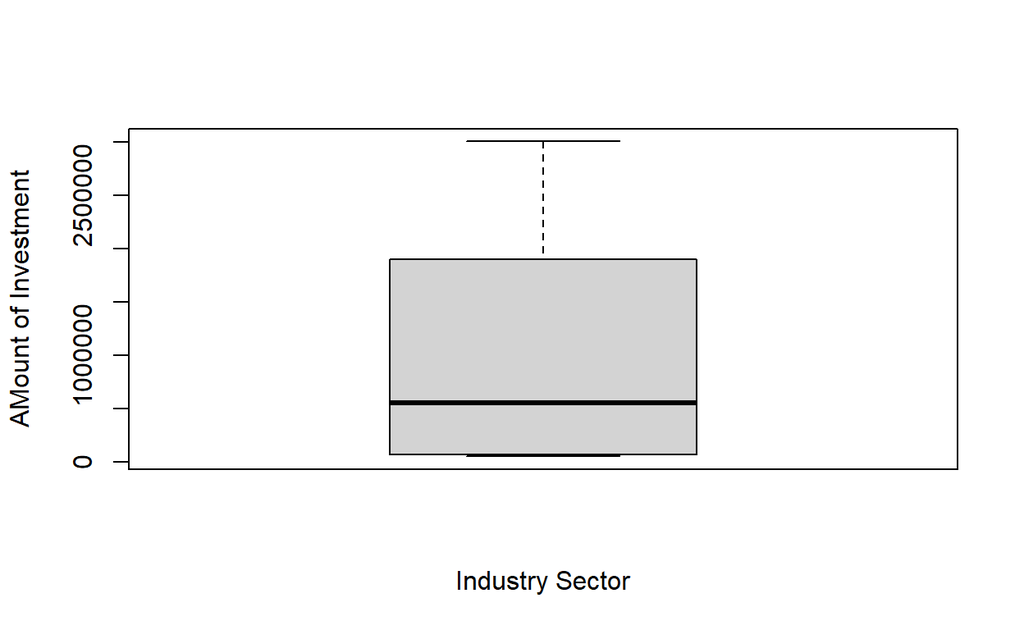

```r
mytable <- xtabs(startup2$year ~ startup2$IndustryVertical)
boxplot.default(mytable, ylab = "AMount of Investment", xlab = "Industry Sector")
```

[figure not shown]

```r
boxplot(startup$IndustryVertical ~ startup$CityLocation,horizontal = TRUE, ylab= "Amount of Investment in USD", xlab = "City", main = "Startup citiwise location Wise Investment Analysis", boxwex = 3)
```

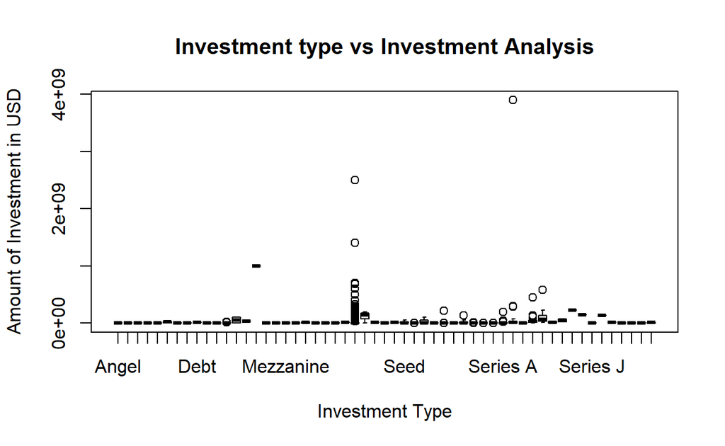

```r
boxplot(startup$AmountUSD ~ startup$InvestmentType,horizontal = FALSE, ylab= "Amount of Investment in USD", xlab = "Investment Type", main = "Investment type vs Investment Analysis")
```

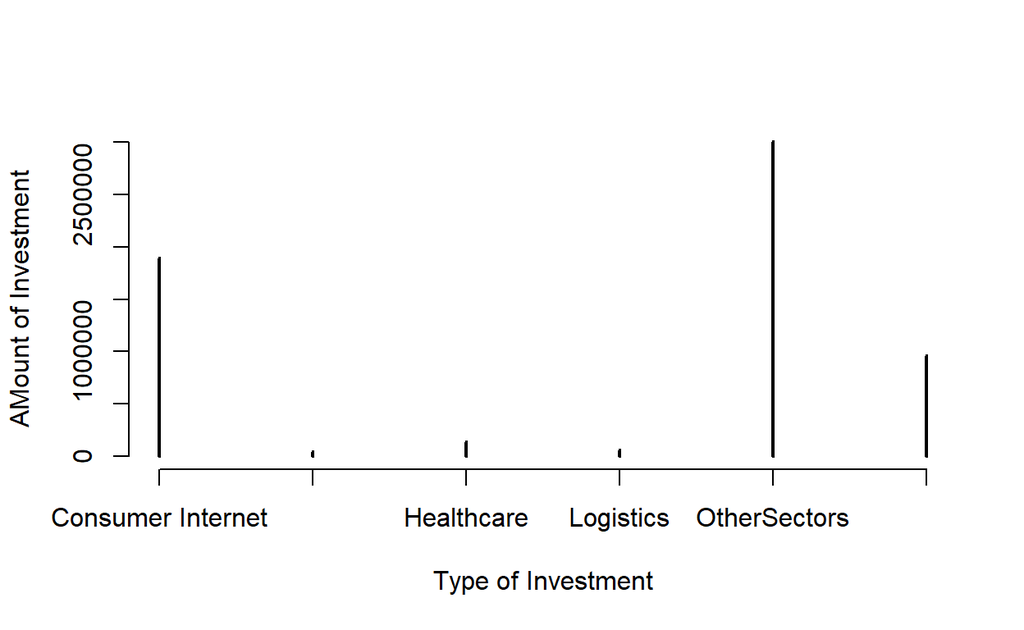

```r
plot(mytable, ylab = "AMount of Investment", xlab = "Type of Investment")
```

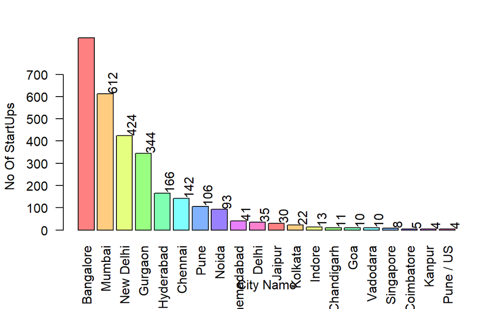

```r
b = barplot(head(sort(table(startup$CityLocation), decreasing=T),20),col=rainbow(10,0.5), las=2, ylim=c(0,750), xlab="City Name", ylab="No Of StartUps")
text(b,head(sort(table(startup$CityLocation), decreasing=T),20),head(sort(table(startup$CityLocation), decreasing=T),20),srt=90, pos=4)
```

```r
##Investor frequency table
Investortable <- head(sort(table(startup2$Investors), decreasing=TRUE))
Investortable
```

```
Undisclosed Investors            Ratan Tata  Indian Angel Network
                  104                    25                    24
     Shell Foundation       Kalaari Capital       Sequoia Capital
                   21                    16                    15
```

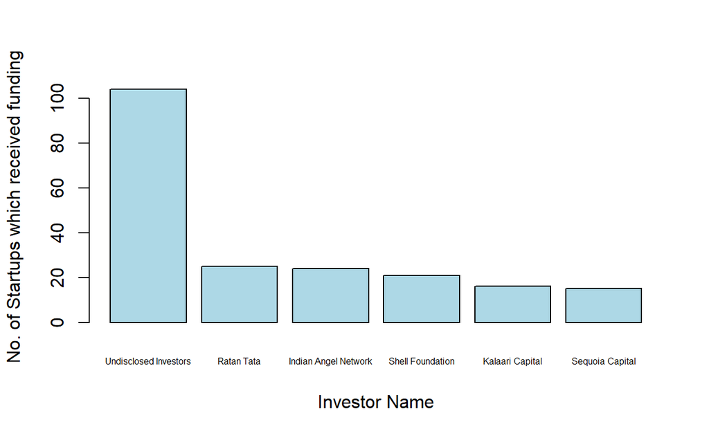

```r
## Visualization using Bar chart
barplot(Investortable, xlab="Investor Name", ylab = "No. of Startups which received funding", col="lightblue",cex.names = 0.5 )
```

[figure not shown]

```r
b = barplot(head(sort(table(startup2$InvestmentType), decreasing=T),20),col=rainbow(10,0.5), las=2, ylim=c(1,1500), xlab="InvestmentType", ylab="Freqency of Investments")
text(b,head(sort(table(startup2$InvestmentType), decreasing=T),20),head(sort(table(startup2$CityLocation), decreasing=T),20),srt=90, pos=4)
```

```r
#generalize the case to prevent misreading on multiple elements with different case
startup2$IndustryVertical <- as.factor(tolower(startup2$IndustryVertical))

#Total amount funded
fund5 <- as.data.frame(aggregate(AmountUSD ~ IndustryVertical, startup, sum))
fund5 <- fund5[order(fund5$AmountUSD, decreasing = TRUE), ] %>%
  drop_na(IndustryVertical) %>%
  head(5)
fund5
```

```
   IndustryVertical  AmountUSD
1        E-Commerce 8189518685
2 Consumer Internet 6323472695
3    Transportation 3916632394
4        Technology 2267804310
5           Finance 1981978000
```

[figure not shown]

```r
ggplot(data = fund5, aes(IndustryVertical, AmountUSD, fill = IndustryVertical)) +
  geom_bar(stat = "identity") +
  coord_flip() +
  scale_y_continuous(labels = unit_format(unit = "M", scale = 0.0000001)) +
  labs(x = "Industry Category", y = "Investment Amount (USD)", title = "TOP 5 Start-up Investment in India") +
  theme(legend.position = "none")
```

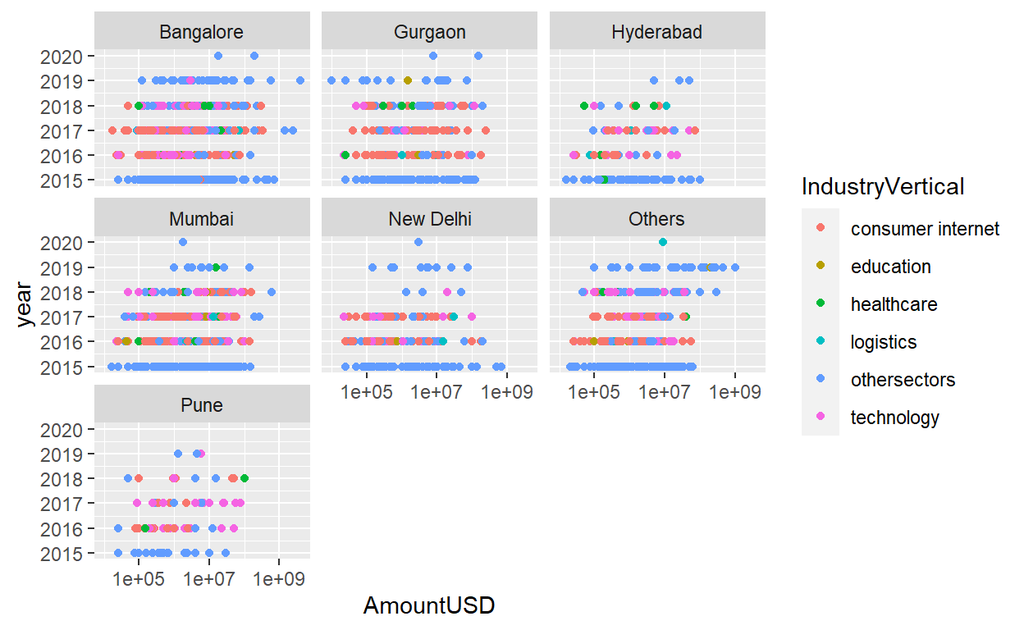

```r
ggplot(startup2, aes(x=AmountUSD, y = year, color = IndustryVertical )) + geom_point() +
scale_x_log10() +
facet_wrap(~CityLocation)
```

The graph shows the distribution of start ups growth in various cities over the years from 2015 to 2020

```r
temp=startup %>% select(StartupName,Investors,AmountUSD) %>% ddply(.(StartupName),summarise,sum=sum(AmountUSD)) %>% arrange(desc(sum))
kable(head(temp,25),"html") %>% kable_styling("striped",full_width=T) %>% column_spec(1:2,bold=T,background="white") %>% row_spec(c(1,2,3,5,6,24,25),bold=F,color="lightblue",background="Green")
```

| StartupName | sum |
| --- | --- |
| Flipkart | 4059700000 |
| Rapido Bike Taxi | 3900000000 |
| Paytm | 3149050000 |
| Ola | 984500000 |
| Udaan | 870000000 |
| Flipkart.com | 700000000 |
| Snapdeal | 700000000 |
| Ola Cabs | 669725000 |
| True North | 600000000 |
| BYJUS | 525240000 |
| BigBasket | 507000000 |
| GOQii | 450331046 |
| Zomato | 435000000 |
| Olacabs | 400000000 |
| Oyo Rooms | 350000000 |
| Automation Anywhere | 300000000 |
| Grofers | 297000000 |
| OYO Rooms | 285000000 |
| Vogo Automotive | 283000000 |
| Swiggy | 270500000 |
| Edelweiss | 270000000 |
| PolicyBazaar | 267700000 |
| Zilingo | 235900000 |
| Lenskart.com | 231000000 |
| Quikr | 230000000 |

The table shows the top start ups and the amounts raised by them. It clearly says Flipkart raised the most funding.

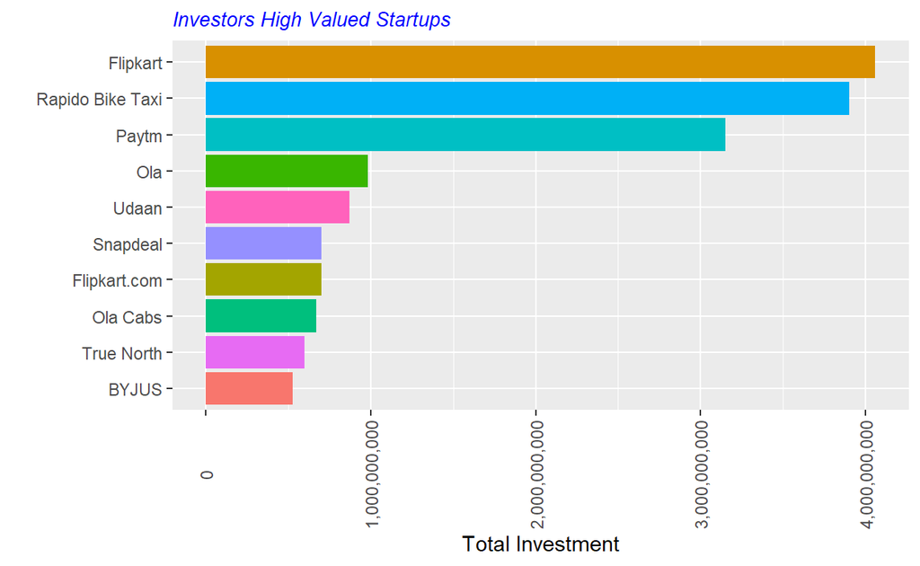

```r
startup2$StartupName=as.factor(startup2$StartupName)

temp=startup2 %>% select(StartupName,Investors,AmountUSD) %>% ddply(.(StartupName),summarise,sum=sum(AmountUSD)) %>% arrange(desc(sum))
#Top 10
ggplot(head(temp,10),aes(reorder(StartupName,sum),sum,fill=StartupName))+geom_bar(stat="identity")+theme(legend.position="none",axis.text.x = element_text(angle=90,vjust=0.5),plot.title=element_text(color="blue",size=10,face="italic"))+labs(x="",y="Total Investment",title="Investors High Valued Startups")+coord_flip()+scale_y_continuous(labels=scales::comma)
```

The table shows the top start ups and the amounts raised by them. It clearly says Flipkart raised the most funding.

# Conclusion:

1. Which startup received the most funding?

   Flipkart
2. Which Industry Vertical received th most funding?

   E-Commerce
3. Does location really matter to raise funding?

# Bibilography:

[Project: Case Study 1 Start-up Funding Analysis | Kaggle](https://www.kaggle.com/code/singhparikshit/project-case-study-1-start-up-funding-analysis/data)

[Home - RDocumentation](https://www.rdocumentation.org/)

[CRAN - Package tidyverse (r-project.org)](https://cran.r-project.org/web/packages/tidyverse/index.html)

[Welcome | R for Data Science (had.co.nz)](https://r4ds.had.co.nz/)